# Accretion, radiation, and variability in astronomy

Research Cluster 3

Cluster 3 centres on how radiation reveals the behaviour of matter around black holes, stars, and galaxies. Accretion—the gathering of material by a central object—and the expulsion of material through jets and winds recur across its communities. Researchers examine both the spectra of that radiation and how its brightness changes over time to infer conditions in regions that are difficult to observe directly.

Black-hole research provides a major focus. One community studies X-ray emission, reflection, and time delays near supermassive black holes in active galactic nuclei. Another foregrounds stellar-mass black holes in X-ray binaries, examining how matter flows through their surrounding disks and what that radiation reveals about black-hole spin. The jet community follows material expelled from active galaxies, particularly blazars, using flares and observations across wavelengths to investigate how jets produce radiation. A further community widens the scale to the host galaxy, asking how black-hole growth relates to star formation and how energy released by an active nucleus affects surrounding gas.

The stellar communities develop related questions in other settings. Research on young stars examines jets and outflows as they encounter the clouds in which stars form. Work on stellar variability follows changes in brightness to investigate pulsation, rotation, and accretion. Across these communities, the motion of gas and changes in radiation provide evidence about the physical processes at work.

Spectroscopy and instrumentation connect several parts of the cluster. Spectra help researchers study matter ranging from gas near black holes to stellar surroundings and supernova remnants. X-ray research also extends to the hot gas between galaxies in galaxy clusters, where turbulence and cooling are central questions. Detectors and telescopes form part of this research through the problem of how to measure the radiation.

Some keyword communities also contain work outside astronomy. These include chemical synthesis and crystal structure, spectroscopic detection, nuclear physics, genetic variation, and environmental processes. These strands broaden the institutional research represented in the cluster, with spectroscopy, X-ray methods, and the study of variability providing points of contact with its astronomical focus.

Three forms of evidence below show what the keyword communities are about and how they relate to one another.

**Interactive keyword network.** Each point represents a keyword, and a line connects two keywords that appear together in one or more publications. The full network shows how keyword communities relate to one another. Select a community from the dropdown to see which terms group together and which connect to terms in other communities. Connections within a community show which subjects, methods, or concepts appear together. Connections across communities show where their vocabularies overlap.

**Community word clouds.** Each cloud shows the vocabulary of one community. Larger words have higher within-community PageRank. This measure reflects both the strength of a keyword’s connections and how well connected its neighbours are. Larger words therefore show which terms are most prominent in the community’s pattern of connections. Smaller words can give those terms context by identifying particular subjects, settings, or methods.

**Affiliated publications.** Each publication has a set of membership values, one for each community. A value of 1 means that all of the publication’s keyword-based membership is assigned to that community. When membership is distributed across communities, the values show how that affiliation is shared. For example, values of 0.7 and 0.3 indicate that the publication’s keywords align more strongly with the first community while also connecting it to the second. The publication lists show how the themes visible in the keyword network are represented in the institution’s research.

[interactive chart not shown]

## Community 1: X-ray variability and accretion in active galactic nuclei

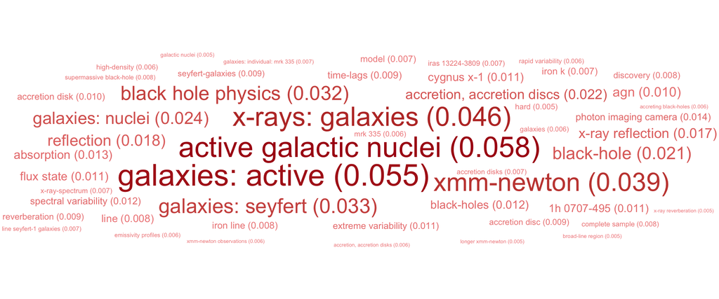

Community 1 of Cluster 3 examines the energetic centres of active galaxies, where matter falling toward a supermassive black hole produces radiation. “Active galactic nuclei” (0.058), “galaxies: active” (0.055), and “X-rays: galaxies” (0.046) have the highest within-community PageRank. “XMM-Newton” (0.039) identifies a prominent observing telescope, while Seyfert galaxies provide a recurring class of objects under study. Accretion disks—the disks of matter surrounding black holes—give the community its physical focus.

This community shares an interest in accretion with Cluster 1’s stellar formation research. There, accretion concerns how young stars gather material as they form. Here, it concerns the behaviour of matter near black holes and what its radiation reveals about conditions in those regions.

## Community 2: Jets and outflows in star-forming regions

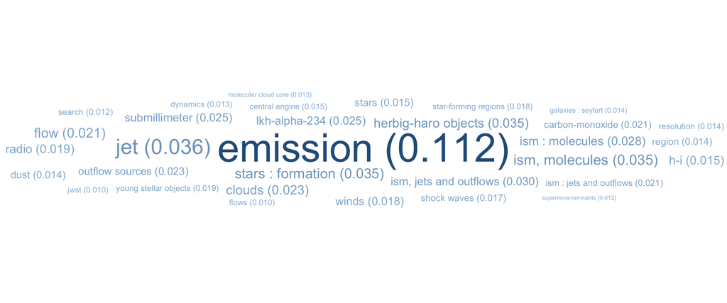

Community 2 of Cluster 3 examines gas expelled by young stars and what its emission reveals about star formation. “Emission” has the highest within-community PageRank (0.112), followed by “jet” (0.036), “Herbig–Haro objects” (0.035), and “stars: formation” (0.035). Herbig–Haro objects are glowing regions produced when outflows from young stars collide with surrounding material. Together with “shock waves,” “winds,” and “young stellar objects,” these terms point to research on how the outflows are driven and how they interact with their surroundings.

The molecular keywords give this work an environmental setting. “Carbon monoxide,” “molecular cloud core,” and “dust” point to the clouds in which stars form, while “radio” and “submillimeter” identify wavelengths used to observe that material. The community brings together questions about the source of an outflow, the motion of the expelled gas, and its effects on the surrounding cloud.

The connection to Community 1 is through the study of emission and material flowing outward from a central source. Community 1 uses X-ray spectra and variability to investigate matter near black holes in active galaxies. Here, the emphasis is on jets and outflows in star-forming regions. This also connects to Cluster 1’s stellar formation community, which foregrounds cloud collapse and the gathering of material by young stars. Community 2 adds attention to the material expelled during that process.

## Community 3: Stellar variability and oscillations

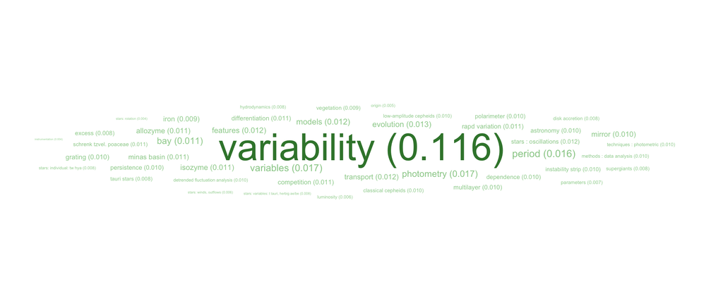

Community 3 of Cluster 3 centres on how stellar brightness varies and what those changes reveal about stars. “Variability” has the highest within-community PageRank (0.116), nearly seven times that of “variables” (0.017), the next-ranked term. “Photometry,” “period,” and “stars: oscillations” point to measurements of brightness over time and the search for recurring patterns. Classical and low-amplitude Cepheids give this work a focus on pulsating stars, while “instability strip” identifies the conditions under which certain stars pulsate. T Tauri stars and disk accretion add research on variability in young stars, where changes in brightness can accompany the gathering of material.

The connection to Community 1 is through the use of variability to investigate physical processes. There, changes in X-ray emission provide clues to conditions near black holes. Here, brightness variations help researchers investigate stellar pulsation, rotation, and accretion. The young-star keywords also overlap with Community 2’s work on jets and outflows, adding attention to how these systems change over time. Terms such as “grating,” “mirror,” and “polarimeter” indicate a strand on astronomical instrumentation.

The community also contains vocabulary from other fields. “Isozyme,” “allozyme,” “RAPD variation,” and “Poaceae” point to genetic variation and differentiation in grasses. “Minas Basin,” “transport,” and “vegetation” suggest environmental research. “Variability” therefore spans several subjects within this grouping, with the astronomical terms providing its clearest substantive focus.

## Community 4: X-ray astronomy

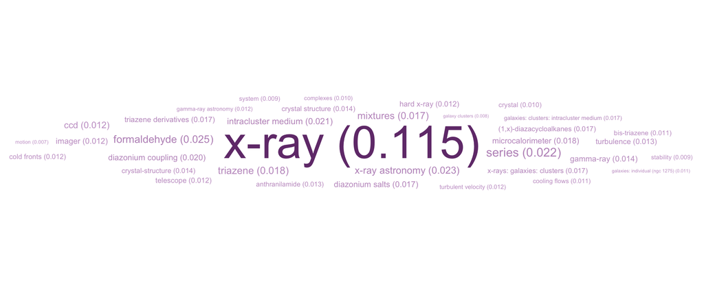

Community 4 of Cluster 3 brings together X-ray astronomy and research on chemical compounds and their structures. “X-ray” has the highest within-community PageRank (0.115), well ahead of “formaldehyde” (0.025) and “X-ray astronomy” (0.023). The astronomical vocabulary centres on the intracluster medium, the hot gas between galaxies in a galaxy cluster. “Turbulence,” “turbulent velocity,” “cold fronts,” and “cooling flows” point to questions about how that gas moves, exchanges heat, and cools. “Microcalorimeter,” “CCD,” “imager,” and “telescope” give the community an instrumentation strand concerned with detecting and measuring X-ray and gamma-ray emission.

The closest connection to Community 1 is through X-ray observations. Community 1 focuses on accretion and radiation near black holes in active galaxies. Here, the astronomical terms give more attention to gas distributed across galaxy clusters. The detector vocabulary also connects to Community 3’s work on astronomical instrumentation, with an emphasis on instruments for observing high-energy radiation.

A distinct chemical strand is visible in “diazonium coupling,” “diazonium salts,” “triazene,” and “triazene derivatives.” These terms point to the preparation and study of nitrogen-containing compounds, while “crystal structure” indicates research on their atomic arrangements. This gives the community a connection to Cluster 7’s structural chemistry. X-rays provide a methodological point of contact between the astronomical and chemical research, serving both to observe cosmic sources and to determine crystal structures.

## Community 5: Spectroscopy and the physical conditions of matter

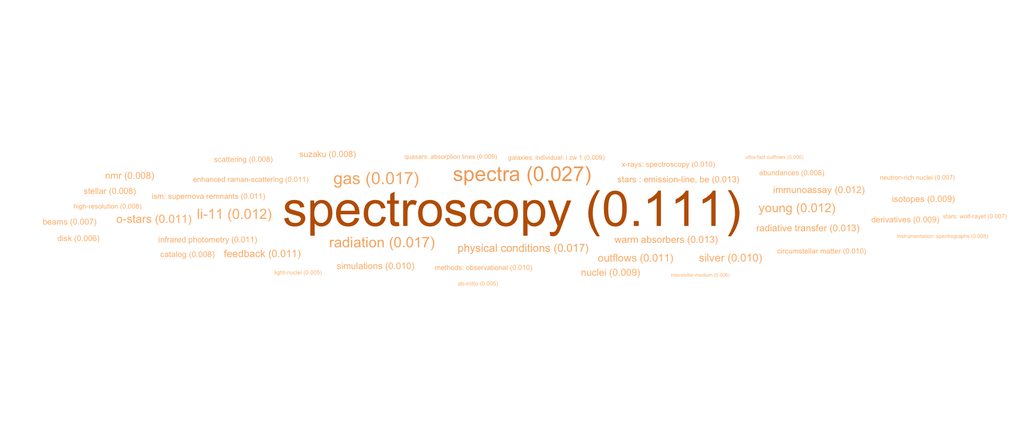

Community 5 of Cluster 3 brings together research that uses spectra to investigate the composition, structure, and physical conditions of matter. “Spectroscopy” has the highest within-community PageRank (0.111), more than four times that of “spectra” (0.027). “Radiation,” “physical conditions,” “gas,” and “radiative transfer” give the astronomical work a focus on what happens as radiation travels through matter. Emission and absorption features provide evidence about the material producing or intercepting that radiation. The objects under study range from emission-line stars and their surrounding material to supernova remnants, quasars, and gas flowing outward from active galactic nuclei.

This community develops a method shared across the preceding communities. Community 1 uses X-ray spectra and variability to investigate accretion near black holes. Community 2 studies emission from stellar jets and outflows, while Community 4 examines hot gas in galaxy clusters. Here, spectroscopy itself provides the organizing focus across several astronomical settings. “Warm absorbers,” “quasars: absorption lines,” and “ultra-fast outflows” give a particular connection to Community 1 through questions about gas near active galactic nuclei.

The vocabulary also extends beyond astronomy. “Enhanced Raman scattering,” “silver,” and “immunoassay” point to work on spectroscopic detection and measurement, while “NMR” identifies another way of probing molecular environments. “Neutron-rich nuclei,” “light nuclei,” “isotopes,” and “beams” indicate a nuclear physics strand. Spectroscopy gives these subjects a methodological connection through the use of measured signals to infer properties of matter.

## Community 6: Black-hole accretion

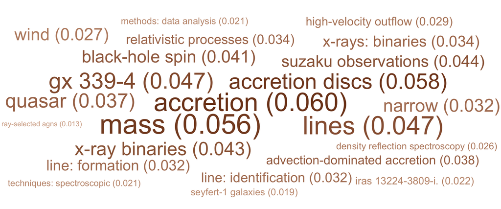

Community 6 of Cluster 3 examines how matter flows toward black holes and how its radiation reveals their properties. “Accretion” (0.060), “accretion discs” (0.058), and “mass” (0.056) lead the within-community PageRank ranking. “GX 339-4” and “X-ray binaries” give the community a focus on systems in which a black hole draws material from a companion star. “Black-hole spin,” “relativistic processes,” and “reflection spectroscopy” point to research that uses radiation from the surrounding disk to investigate conditions close to the black hole. “Wind” and “high-velocity outflow” extend the inquiry to material expelled from these systems.

The closest connection is to Community 1, which also uses X-ray observations to study accretion and reflection. Community 1 foregrounds the supermassive black holes in active galactic nuclei. Here, X-ray binaries bring stellar-mass black holes into the foreground, while “quasar” and “Seyfert-1 galaxies” retain a connection to the larger systems. This gives the cluster a basis for examining accretion across different black-hole masses. The emphasis on spectral lines and their identification also connects to Community 5’s use of spectroscopy to infer physical conditions from radiation.

## Community 7: Supermassive black holes and galaxy evolution

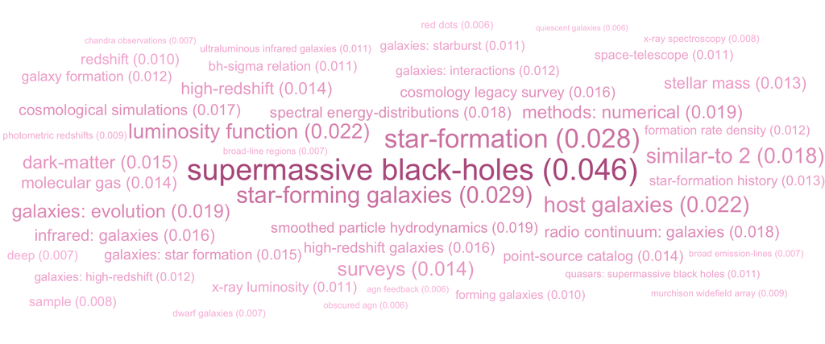

Community 7 of Cluster 3 examines how the growth of supermassive black holes relates to the development of their host galaxies. “Supermassive black holes” has the highest within-community PageRank (0.046), followed by “star-forming galaxies” (0.029) and “star formation” (0.028). Together with “stellar mass,” “molecular gas,” and “star-formation history,” these terms point to questions about how galaxies build their stars while their central black holes grow. “AGN feedback” adds an interest in how energy released near a black hole affects the gas from which stars form.

The community combines observations of galaxy populations with numerical models. “Surveys,” “infrared: galaxies,” and “radio continuum: galaxies” identify ways of observing galaxies, while “spectral energy distributions” points to using radiation across wavelengths to estimate their properties. High-redshift galaxies provide evidence about earlier periods in cosmic history. Cosmological simulations offer a way to examine how black holes, gas, stars, and dark matter develop together.

The closest connection is to Community 1’s work on active galactic nuclei. There, the emphasis is on what radiation and variability reveal about the region near a black hole. Here, the scope widens to the host galaxy and to patterns across galaxy populations. It also connects to Community 6 through black-hole mass and growth, and to Community 2 through the effects of outflows on surrounding gas. This community develops the cluster’s interest in accretion into questions about how black-hole activity and star formation enter into the history of galaxies.

## Community 8: Relativistic jets

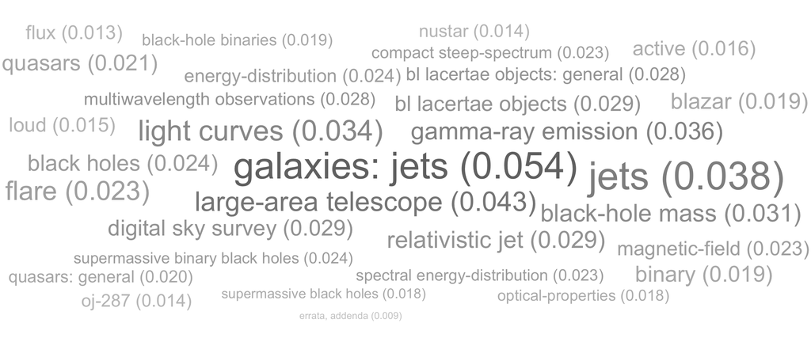

Community 8 of Cluster 3 examines jets launched from the centres of active galaxies and the radiation they produce. “Galaxies: jets” has the highest within-community PageRank (0.054), followed by “large-area telescope” (0.043), “jets” (0.038), and “gamma-ray emission” (0.036). “Blazar” and “BL Lacertae objects” identify systems whose jets point close to our line of sight. “Light curves,” “flare,” and “multiwavelength observations” point to research that follows changes in brightness across different parts of the electromagnetic spectrum. These observations help researchers investigate how particles are energized and how magnetic fields contribute to jet emission.

The community also includes a strand on black-hole systems. “Supermassive binary black holes,” “black-hole mass,” and “OJ 287” point to questions about whether the behaviour of some active galaxies can be explained by two black holes orbiting one another.

The closest connection is to Community 1’s study of radiation and variability near supermassive black holes. Here, jets and their gamma-ray emission provide the main focus. The community also shares Community 2’s interest in outflows, extending that inquiry from young stars to relativistic jets in galaxies. Community 7 examines black holes in relation to their host galaxies, while this grouping gives more attention to the jet and the changes in radiation reaching the observer.

## Most cited publications by community

Select one of the communities above to populate the table. The table shows up to five publications per selected research community, arranged by highest Total Citation count within the research community under consideration. Under Membership vector the column headers indicate abbreviated research community labels. Each row sum totals 1.0. Values of 1 indicate maximal research community affiliation; distributed values indicate multithematic papers whose affiliation reaches into more than one research community (Aria et al. 2026; Aria and Cuccurullo 2026). TCpY = Total Citations per Year.

Community:

| Publication title | Year | TC | TCpY | Membership vector Xvr | Membership vector Emi | Membership vector Ste | Membership vector instrumentation, and chemical structure,Xas | Membership vector Spe | Membership vector spin, and X-ray binaries,Bla | Membership vector Sup | Membership vector blazars, and black-hole systems,Bhm |
| --- | --- | --- | --- | --- | --- | --- | --- | --- | --- | --- | --- |
| x-Ray Reverberation Around Accreting Black Holes | 2014 | 425 | 32.7 | 0.9 | 0.0 | 0.0 | 0.0 | 0.0 | 0.1 | 0.0 | 0.0 |
| Suzaku Observations of 'bare' Active Galactic Nuclei | 2013 | 263 | 18.8 | 0.9 | 0.0 | 0.0 | 0.0 | 0.0 | 0.1 | 0.0 | 0.0 |
| Broad Iron l Line and x-Ray Reverberation in 1h0707-495 | 2010 | 217 | 12.8 | 1.0 | 0.0 | 0.0 | 0.0 | 0.0 | 0.0 | 0.0 | 0.0 |
| Modelling the Broad Fe Kα Reverberation in the Agn Ngc 4151 | 2014 | 130 | 10.0 | 1.0 | 0.0 | 0.0 | 0.0 | 0.0 | 0.0 | 0.0 | 0.0 |
| The Response of Relativistic Outflowing Gas to the Inner Accretion Disk of a Black Hole | 2017 | 124 | 12.4 | 0.6 | 0.0 | 0.0 | 0.0 | 0.2 | 0.1 | 0.0 | 0.1 |
| Molecular Oxygen in the Ρophiuchi Cloud | 2007 | 141 | 7.0 | 0.0 | 1.0 | 0.0 | 0.0 | 0.0 | 0.0 | 0.0 | 0.0 |
| Oh (1720 Mhz) Masers as Signposts of Molecular Shocks | 1998 | 92 | 3.2 | 0.0 | 0.9 | 0.0 | 0.0 | 0.1 | 0.0 | 0.0 | 0.0 |
| Formation of a Low-Mass Galaxy from Star Clusters in a 600-Million-Year-Old Universe | 2024 | 68 | 22.7 | 0.0 | 0.7 | 0.3 | 0.0 | 0.0 | 0.0 | 0.0 | 0.0 |
| Formation of Cavities in the x-Ray Emitting Cluster Gas of Cygnus a | 1997 | 62 | 2.1 | 0.0 | 0.7 | 0.3 | 0.0 | 0.0 | 0.0 | 0.0 | 0.0 |
| Diffraction-Limited Bispectrum Speckle Interferometry of the Nuclear Region of the Seyfert Galaxy Ngc 1068 in the h and K′ Bands | 2004 | 56 | 2.4 | 0.2 | 0.8 | 0.0 | 0.0 | 0.0 | 0.0 | 0.0 | 0.0 |
| The Effect of Environmental Heterogeneity on Species Richness Depends on Community Position along the Environmental Gradient | 2015 | 128 | 10.7 | 0.0 | 0.0 | 1.0 | 0.0 | 0.0 | 0.0 | 0.0 | 0.0 |
| Rate of Period Change as a Diagnostic of Cepheid Properties | 2006 | 127 | 6.0 | 0.0 | 0.0 | 1.0 | 0.0 | 0.0 | 0.0 | 0.0 | 0.0 |
| Most Detects g- and p-Modes in the b Supergiant Hd 163899 (B2 Ib/Ii) | 2006 | 98 | 4.7 | 0.0 | 0.0 | 1.0 | 0.0 | 0.0 | 0.0 | 0.0 | 0.0 |
| Climate Change, Uncertainty, and Resilient Fisheries: Institutional Responses Through Integrative Science | 2010 | 76 | 4.5 | 0.0 | 0.0 | 1.0 | 0.0 | 0.0 | 0.0 | 0.0 | 0.0 |
| Phonological Contrast and Its Phonetic Enhancement: Dispersedness without Dispersion | 2011 | 52 | 3.2 | 0.0 | 0.0 | 1.0 | 0.0 | 0.0 | 0.0 | 0.0 | 0.0 |
| Atmospheric Gas Dynamics in the Perseus Cluster Observed with Hitomi | 2018 | 139 | 15.4 | 0.0 | 0.0 | 0.0 | 0.9 | 0.0 | 0.1 | 0.0 | 0.0 |
| Concept of x-Ray Astronomy Recovery Mission | 2018 | 133 | 14.8 | 0.0 | 0.0 | 0.0 | 0.9 | 0.1 | 0.0 | 0.0 | 0.0 |
| Structurally Simple Complexes of Co2 | 2015 | 119 | 9.9 | 0.0 | 0.0 | 0.0 | 1.0 | 0.0 | 0.0 | 0.0 | 0.0 |
| Status of x-Ray Imaging and Spectroscopy Mission (Xrism) | 2021 | 98 | 16.3 | 0.0 | 0.0 | 0.0 | 1.0 | 0.0 | 0.0 | 0.0 | 0.0 |
| The Astro-h (Hitomi) x-Ray Astronomy Satellite | 2016 | 81 | 7.4 | 0.0 | 0.0 | 0.0 | 0.7 | 0.1 | 0.0 | 0.0 | 0.1 |
| Development of a Sers-Based Rapid Vertical Flow Assay for Point-of Care Diagnostics | 2017 | 86 | 8.6 | 0.0 | 0.0 | 0.0 | 0.0 | 1.0 | 0.0 | 0.0 | 0.0 |
| Interplay Between Steric and Electronic Factors in Determining the Strength of Intramolecular Resonance-Assisted Nh-o Hydrogen Bond in a Series of β-Ketoarylhydrazones | 1999 | 80 | 2.9 | 0.0 | 0.0 | 0.2 | 0.2 | 0.5 | 0.0 | 0.0 | 0.0 |
| Evidence of Soft Dipole Resonance in 11li with Isoscalar Character | 2015 | 53 | 4.4 | 0.0 | 0.0 | 0.0 | 0.0 | 1.0 | 0.0 | 0.0 | 0.0 |
| Structure of the Room-Temperature Ionic Liquid 1-Hexyl-3-Methylimidazolium Hydrogen Sulfate: Conformational Isomerism | 2010 | 41 | 2.4 | 0.0 | 0.0 | 0.0 | 0.0 | 1.0 | 0.0 | 0.0 | 0.0 |
| β Decay of 32na | 2007 | 37 | 1.9 | 0.0 | 0.2 | 0.0 | 0.0 | 0.8 | 0.0 | 0.0 | 0.0 |
| Stellar-Mass Black Hole Spin Constraints from Disk Reflection and Continuum Modeling | 2009 | 222 | 12.3 | 0.4 | 0.0 | 0.0 | 0.0 | 0.0 | 0.6 | 0.0 | 0.0 |
| How the Effects of Resonant Absorption on Black Hole Reflection Spectra can Mimic High-Velocity Outflows | 2011 | 23 | 1.4 | 0.3 | 0.0 | 0.0 | 0.0 | 0.0 | 0.7 | 0.0 | 0.0 |
| The Origin of Blueshifted Absorption Features in the x-Ray Spectrum of Pg 1211+143: Outflow or Disc | 2013 | 22 | 1.6 | 0.3 | 0.0 | 0.0 | 0.0 | 0.0 | 0.7 | 0.0 | 0.0 |
| a Nustar and Swift View of the Hard State of Maxi J1813-095 | 2022 | 7 | 1.4 | 0.2 | 0.0 | 0.0 | 0.0 | 0.0 | 0.8 | 0.0 | 0.0 |
| Enhanced Star Formation in Narrow-Line Seyfert 1 Active Galactic Nuclei Revealed by Spitzer | 2010 | 120 | 7.1 | 0.2 | 0.0 | 0.0 | 0.0 | 0.0 | 0.1 | 0.6 | 0.2 |
| a Comparative Study of Agn Feedback Algorithms | 2013 | 64 | 4.6 | 0.2 | 0.0 | 0.0 | 0.0 | 0.0 | 0.0 | 0.8 | 0.0 |
| On the Lack of Correlation Between [o Iii]/[o Ii] and Lyman Continuum Escape Fraction | 2019 | 56 | 7.0 | 0.2 | 0.0 | 0.0 | 0.0 | 0.0 | 0.0 | 0.8 | 0.0 |
| Suzaku Observations of Local Ultraluminous Infrared Galaxies | 2009 | 48 | 2.7 | 0.3 | 0.0 | 0.0 | 0.0 | 0.0 | 0.0 | 0.7 | 0.0 |
| Clear: High-Ionization [ne V] Λ3426 Emission-Line Galaxies at 1.4 &lt; z &lt; 2.3 | 2023 | 32 | 8.0 | 0.1 | 0.0 | 0.0 | 0.1 | 0.0 | 0.0 | 0.7 | 0.0 |
| Properties of Flat-Spectrum Radio-Loud Narrow-Line Seyfert 1 Galaxies | 2015 | 160 | 13.3 | 0.4 | 0.0 | 0.0 | 0.0 | 0.0 | 0.0 | 0.0 | 0.6 |
| Radio-to-γ-Ray Monitoring of the Narrow-Line Seyfert 1 Galaxy Pmn J0948+0022 from 2008 to 2011 | 2012 | 48 | 3.2 | 0.2 | 0.0 | 0.1 | 0.0 | 0.0 | 0.1 | 0.0 | 0.6 |
| The Multiwavelength View of Shocks in the Fastest Nova V1674 Her | 2023 | 23 | 5.8 | 0.2 | 0.0 | 0.0 | 0.2 | 0.0 | 0.0 | 0.0 | 0.5 |
| Momo. Iv. the Complete Swift x-Ray and Uv/Optical Light Curve and Characteristic Variability of the Blazar Oj 287 During the Last Two Decades | 2021 | 22 | 3.7 | 0.3 | 0.1 | 0.0 | 0.0 | 0.0 | 0.0 | 0.0 | 0.6 |
| Project Momo: Multiwavelength Observations and Modeling of Oj 287 | 2021 | 21 | 3.5 | 0.2 | 0.1 | 0.1 | 0.0 | 0.0 | 0.0 | 0.0 | 0.6 |

## References

Aria, Massimo, and Corrado Cuccurullo. 2026. *Science Mapping Analysis: A Primer with Biblioshiny*. Mailand: McGraw-Hill Education.

Aria, Massimo, Luca D’Aniello, Michelangelo Misuraca, and Maria Spano. 2026. “Rethinking Thematic Evolution in Science Mapping:an Integrated Framework for Longitudinal Analysis.” *Journal of Informetrics* 20 (4): 101877. https://doi.org/10.1016/j.joi.2026.101877.